# PEP2

2023-12-14

# Pregunta 1

Se agregan las librerias necesarias para el analisis de los datos

```r
set.seed(123)
library(ggplot2)
library(dplyr)
library(caret)
library(car)
```

Se leen el archivo de los datos

```r
datos <- read.csv2("EI-2023-2-PE2-Datos-Equipo11.csv", header = TRUE, sep = ",", fileEncoding = "utf8")
```

La pregunta propuesta es: ¿Es posible predecir la variable X5 utilizando el resto de las variables medidas en el conjunto de los datos?

Se puede notar que la naturaleza de la variable no es categorica y menos dicotomica, por lo tanto, como se debe hacer un modelo con multiples variables se utilizará la regresión lineal multiple.

```r
# Se crea el modelo con todas las variables
modelo <- lm(X5 ~ ., data = datos)
print(summary(modelo))
```

```
##
## Call:
## lm(formula = X5 ~ ., data = datos)
##
## Residuals:
##     Min      1Q  Median      3Q     Max
## -316.07 -131.92   -7.82   99.23  624.94
##
## Coefficients:
##             Estimate Std. Error t value Pr(>|t|)
## (Intercept) 205.4157   368.6362   0.557   0.5804
## X1           -3.0575     5.7238  -0.534   0.5961
## X2           -0.2892     0.7524  -0.384   0.7027
## X3            3.1384     3.7192   0.844   0.4037
## X4            3.1563     2.7767   1.137   0.2623
## X6            9.7303     8.1761   1.190   0.2409
## X7           -1.2164     3.8543  -0.316   0.7539
## X8            2.3983     1.3730   1.747   0.0882 .
## X9           -0.3167    10.5983  -0.030   0.9763
## ---
## Signif. codes:  0 '***' 0.001 '**' 0.01 '*' 0.05 '.' 0.1 ' ' 1
##
## Residual standard error: 190.8 on 41 degrees of freedom
## Multiple R-squared:  0.6473, Adjusted R-squared:  0.5785
## F-statistic: 9.405 on 8 and 41 DF,  p-value: 2.926e-07
```

Se puede notar que la mayoría tiene poca importancia y esto se puede deber a alguna existencia de multicolinealidad, por esto se utilizará el valor de inflación de la variancia con la función VIF de la librería car para utilizarlo como criterio de eliminación de predictores que podrían ser colineales a la variable predictora.

```r
print(vif(modelo))
```

```
##         X1         X2         X3         X4         X6         X7         X8
##   4.377187 250.735913 247.250002   1.913679   3.263478   4.378432   2.618907
##         X9
##   4.019737
```

Variables que podemos notar inmediatamente que se deben eliminar son X2 y X3, ya que, estas tiene un VIF demasiado alto siendo 250.735913 y 247.250002 respectivamente.

Se procede a elimnar estas variables predictoras

```r
modelo <- update(modelo, . ~ . - X2 - X3)
print(summary(modelo))
```

```
##
## Call:
## lm(formula = X5 ~ X1 + X4 + X6 + X7 + X8 + X9, data = datos)
##
## Residuals:
##     Min      1Q  Median      3Q     Max
## -350.31 -154.49  -68.59  133.53  735.83
##
## Coefficients:
##             Estimate Std. Error t value Pr(>|t|)
## (Intercept)  580.616    482.990   1.202 0.235893
## X1            -9.229      7.442  -1.240 0.221693
## X4            11.148      3.143   3.547 0.000955 ***
## X6             4.947     10.099   0.490 0.626722
## X7            -1.819      5.059  -0.359 0.721013
## X8             1.614      1.812   0.891 0.378001
## X9             6.944     13.891   0.500 0.619718
## ---
## Signif. codes:  0 '***' 0.001 '**' 0.01 '*' 0.05 '.' 0.1 ' ' 1
##
## Residual standard error: 253.9 on 43 degrees of freedom
## Multiple R-squared:  0.3454, Adjusted R-squared:  0.254
## F-statistic: 3.781 on 6 and 43 DF,  p-value: 0.004123
```

Ahora en el resumen del modelo se puede notar que la variable que tiene mayor importancia es X4 para el modelo, las demas al no tener podría tener colinealidad con la variable dependiente X5.

Ahora se vuelve a comprobar el VIF de las variables predictoras

```r
print(vif(modelo))
```

```
##       X1       X4       X6       X7       X8       X9
## 4.181815 1.385237 2.813446 4.263346 2.577807 3.902190
```

Se puede notar que en general todos los VIF de las varaibles predictoras mejoraron, pero aún se tienen tres variables que se considera que estan por sobre el umbral definido en el enunciado (VIF <= 3), pero también se indica que se debe detener cuando se eliminen 3 de las variables predictoras originales o todos los VIF sean menor o igual a 3, en este caso como ya se ha elimnado dos de las variables predictoras originales se procede con elimnar una más, siendo esta X7 que tiene el mayor VIF siendo un 4.263346.

```r
modelo <- update(modelo, . ~ . - X7)
print(summary(modelo))
```

```
##
## Call:
## lm(formula = X5 ~ X1 + X4 + X6 + X8 + X9, data = datos)
##
## Residuals:
##     Min      1Q  Median      3Q     Max
## -346.03 -151.79  -69.61  134.31  739.68
##
## Coefficients:
##             Estimate Std. Error t value Pr(>|t|)
## (Intercept)  457.489    337.127   1.357 0.181694
## X1            -7.412      5.410  -1.370 0.177599
## X4            11.363      3.054   3.720 0.000561 ***
## X6             6.803      8.592   0.792 0.432752
## X8             1.299      1.570   0.827 0.412504
## X9             3.696     10.446   0.354 0.725178
## ---
## Signif. codes:  0 '***' 0.001 '**' 0.01 '*' 0.05 '.' 0.1 ' ' 1
##
## Residual standard error: 251.3 on 44 degrees of freedom
## Multiple R-squared:  0.3434, Adjusted R-squared:  0.2688
## F-statistic: 4.603 on 5 and 44 DF,  p-value: 0.001832
```

Se puede notar que sigue siendo X4 el que tiene mayor importancia para el modelo, dejando a todas las demás variables que no tienen mucha importancia con una sospecha de colinealidad.

Se comprueba nuevamente el VIF

```r
print(vif(modelo))
```

```
##       X1       X4       X6       X8       X9
## 2.254393 1.334880 2.077872 1.974571 2.251213
```

Ahora se puede notar que se dieron ambos casos a la vez, se eliminaron 3 variables y todos tienen un VIF menor que 3.

Lo siguiente a evaluar es que tan confiable es este modelo, para esto se deben evaluar las condiciones

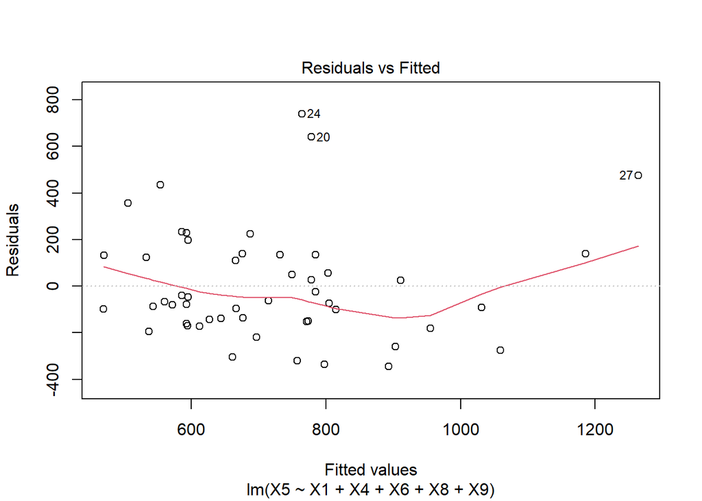

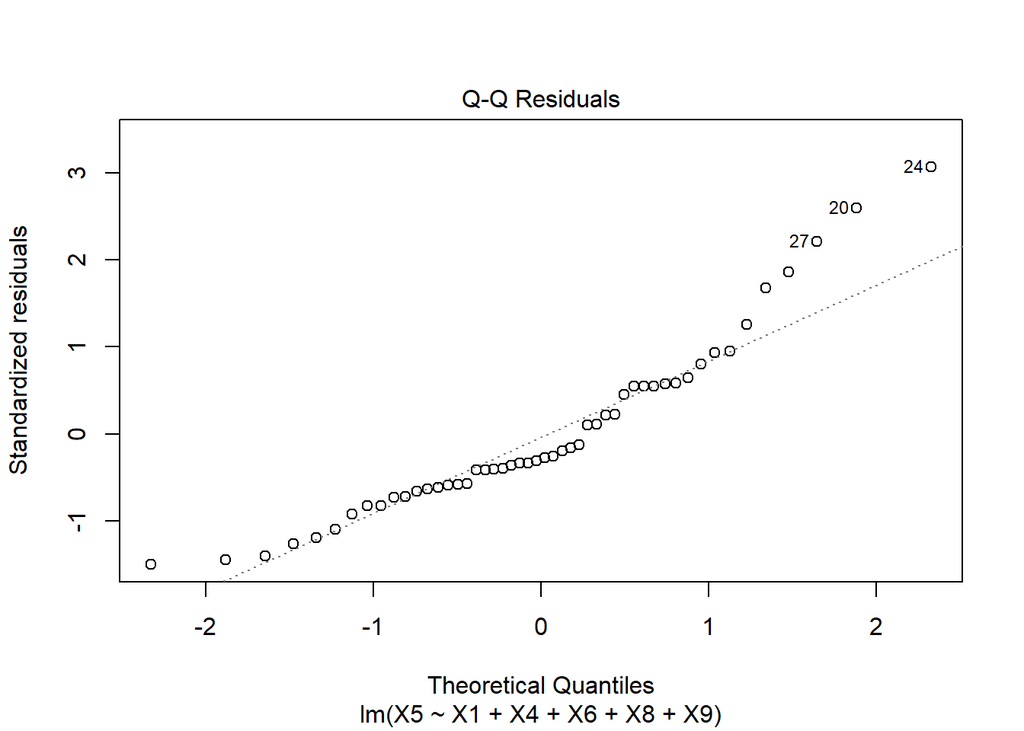

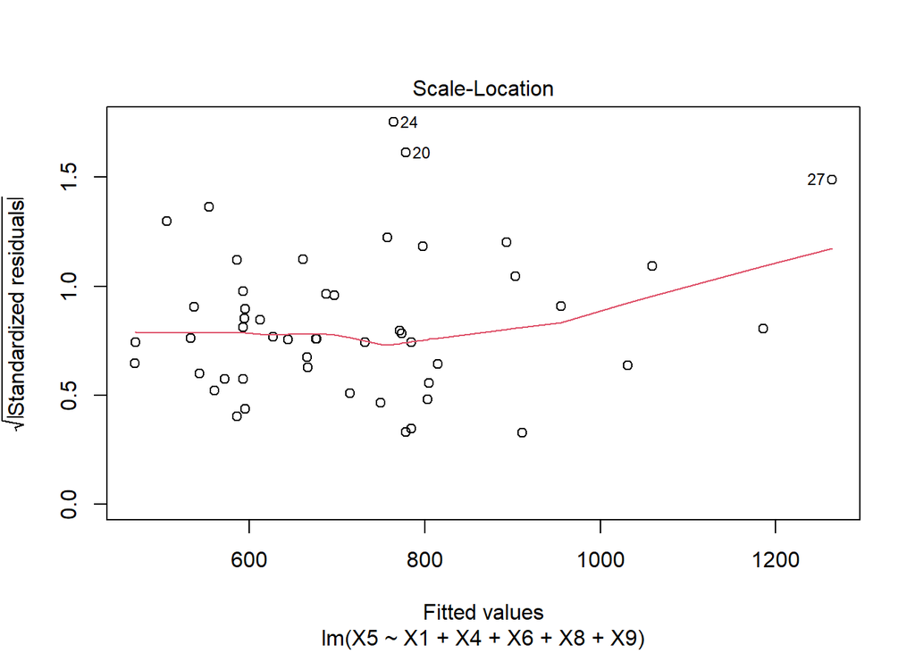

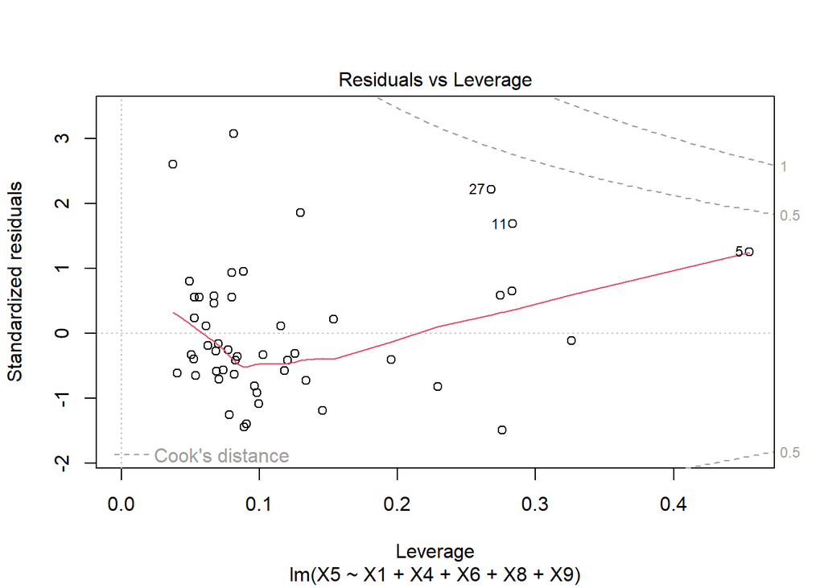

```r
plot(modelo)
```

Al ver los graficos de los residuos del modelo se puede notar que en la condición de normalidad, viendo el grafico Q-Q, estos parecieran seguir una normalidad pero se pueden notar valores atipicos que estan afectando al modelo, esto tiene bastante sentido con el resultado del $R^{2}$ del último modelo presentado el cual tiene un valor de 0.3434 esto indica que el modelo explica el 34.34% de la variabilidad en la variable dependiente.

También se puede ver que existen valores atipicos en el grafico de disperción de los residuos y que estos no se ven totalmente de una manera aleatoria.

Para esto se aplicara la estrategia de la distnacia de cook para detectarlos, estos datos se obtienen del modelo con el which = 4 el cual devuelve las distancias de Cook.

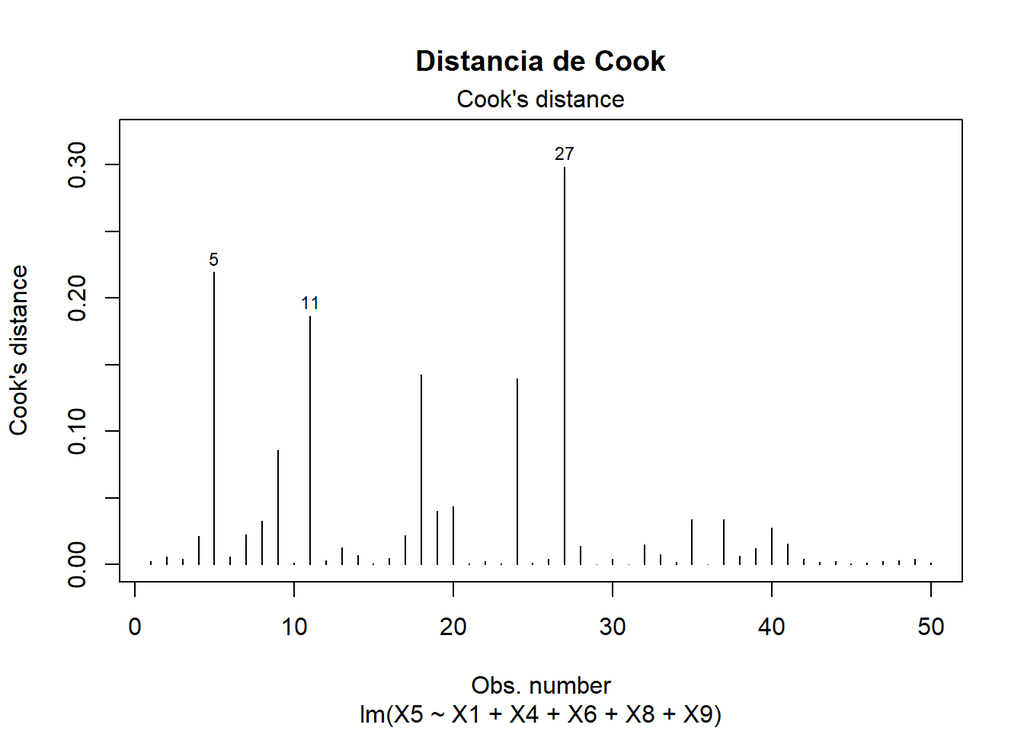

```r
plot(modelo, which=4, main="Distancia de Cook")
```

Se pueden ver que los valores atipicos detectados son 5, 11 y 27, por lo cual se deben eliminar bajo este criterio. Además, como se vio anteriormente en el grafico de disperción de los residuos también se consideran valores atipicos 20 y 24, por lo tanto estos se eliminan bajo este criterio.

```r
datos <- datos[-c(5,11,20,24,27),]
```

Se vuelve a realizar el modelo de RLM con las variables predictoras X1, X4, X6, X8 y X9

```r
modelo <- lm(X5 ~ X1 + X4 + X6 + X8 + X9, data = datos)
print(summary(modelo))
```

```
##
## Call:
## lm(formula = X5 ~ X1 + X4 + X6 + X8 + X9, data = datos)
##
## Residuals:
##     Min      1Q  Median      3Q     Max
## -338.65 -100.03   -8.84  120.07  380.11
##
## Coefficients:
##             Estimate Std. Error t value Pr(>|t|)
## (Intercept) 831.0872   248.5173   3.344 0.001832 **
## X1           -8.1873     3.9460  -2.075 0.044644 *
## X4            9.4906     2.5640   3.701 0.000661 ***
## X6           -0.4104     6.4585  -0.064 0.949656
## X8           -0.7935     1.0919  -0.727 0.471758
## X9            2.6903     8.5194   0.316 0.753846
## ---
## Signif. codes:  0 '***' 0.001 '**' 0.01 '*' 0.05 '.' 0.1 ' ' 1
##
## Residual standard error: 167.3 on 39 degrees of freedom
## Multiple R-squared:  0.4192, Adjusted R-squared:  0.3448
## F-statistic: 5.631 on 5 and 39 DF,  p-value: 0.0005328
```

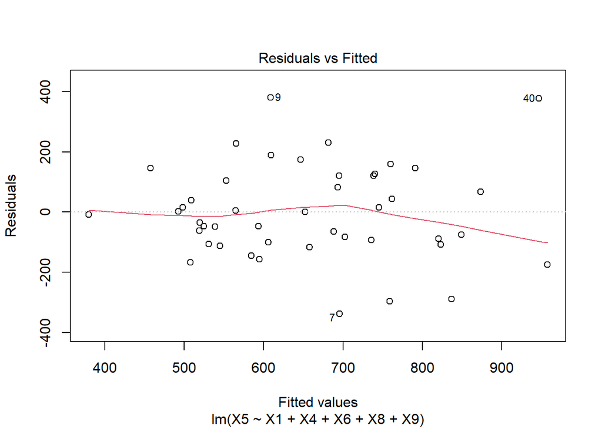

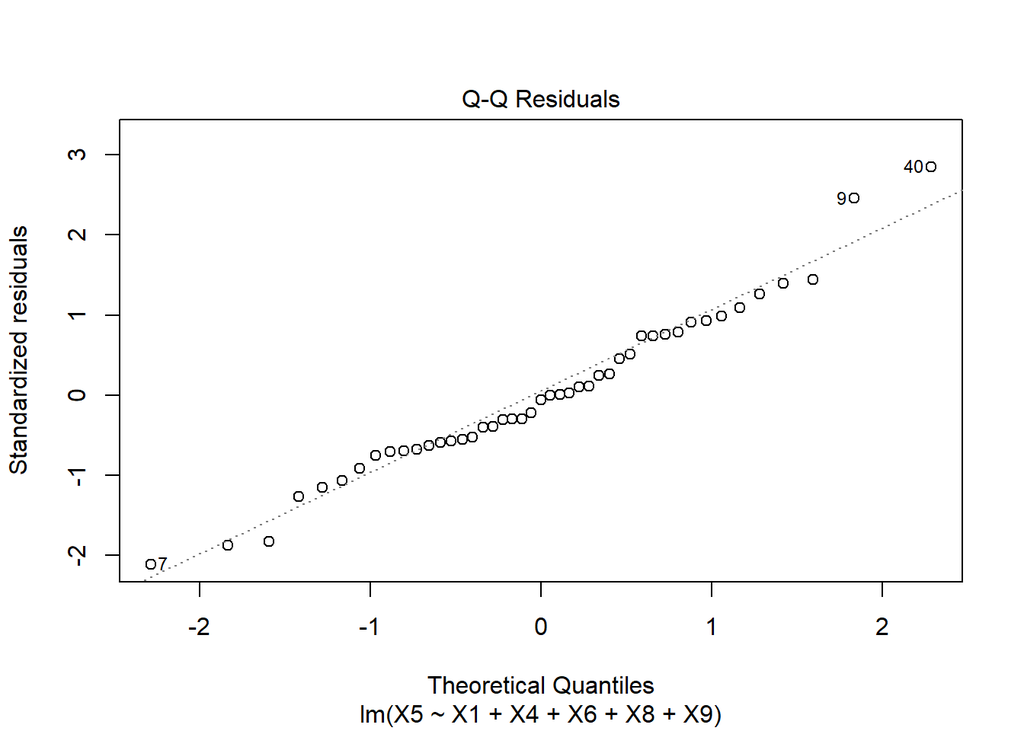

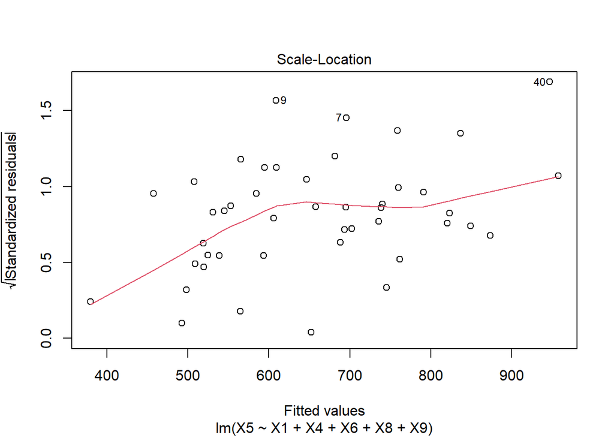

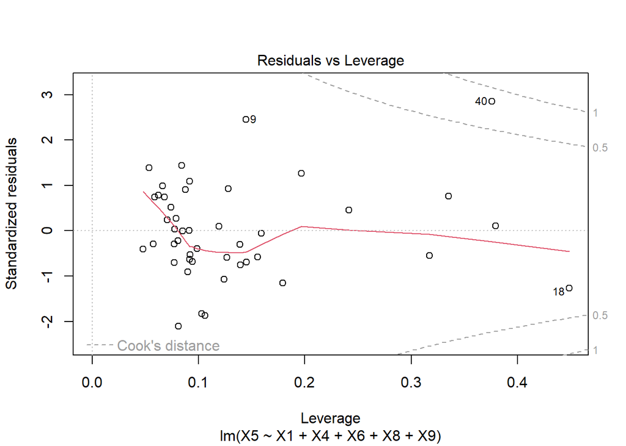

```r
plot(modelo)
```

```r
print(vif(modelo))
```

```
##       X1       X4       X6       X8       X9
## 2.352870 1.508991 2.301655 1.722564 2.065421
```

Se ven las graficas de las variables predictoras contra la variable dependiente

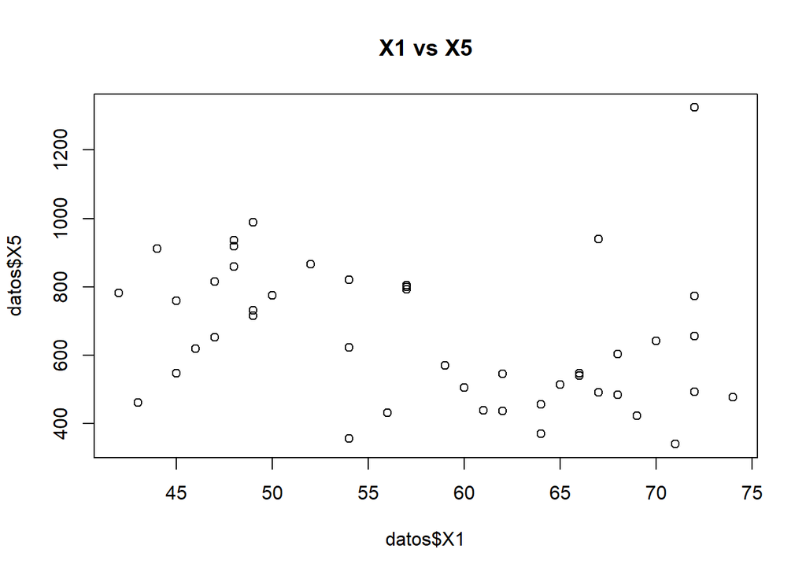

```r
plot(datos$X1, datos$X5, main = "X1 vs X5")
```

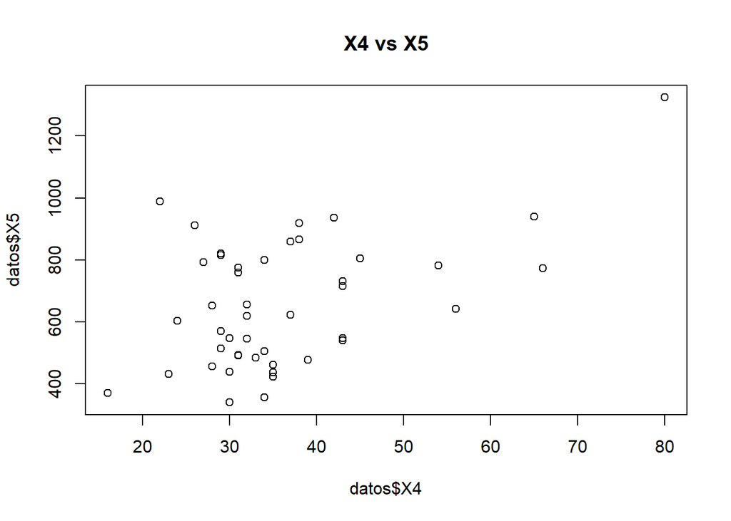

```r
plot(datos$X4, datos$X5, main = "X4 vs X5")
```

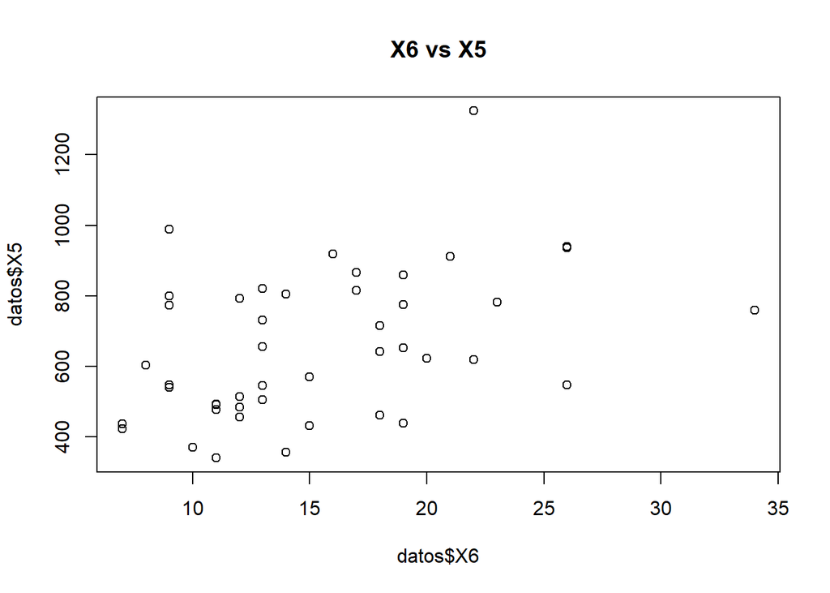

```r
plot(datos$X6, datos$X5, main = "X6 vs X5")
```

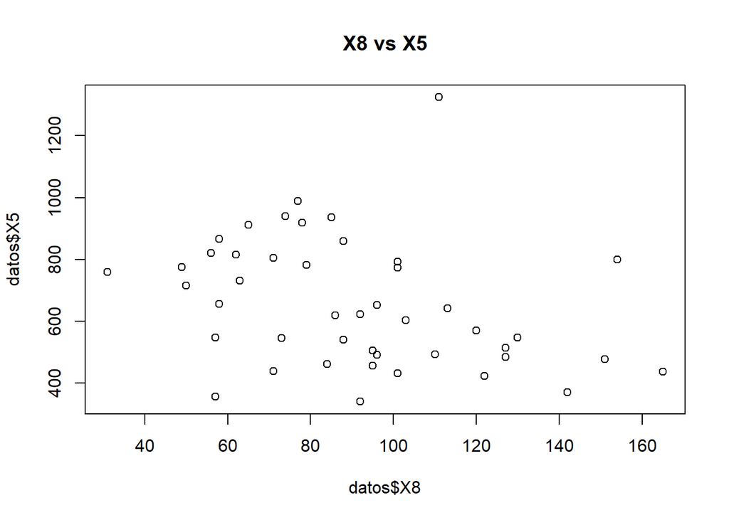

```r
plot(datos$X8, datos$X5, main = "X8 vs X5")
```

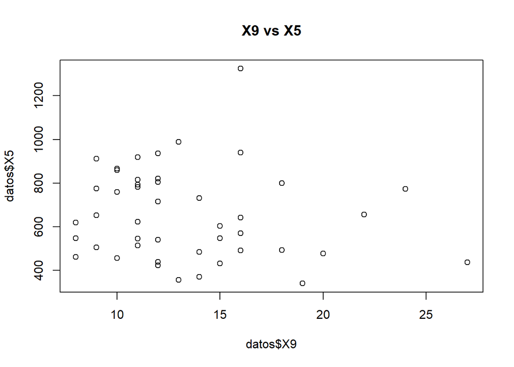

```r
plot(datos$X9, datos$X5, main = "X9 vs X5")
```